# Welcome & Introduction

RAdelaide 2024

Author

Affiliation

Dr Stevie Pederson

Black Ochre Data Labs  
Telethon Kids Institute

Published

July 9, 2024

http://blackochrelabs.au/RAdelaide24

# Introduction

## Who Am I?

**Stephen (Stevie) Pederson** (They/Them)

- Adelaide, Kaurna Country, SA
- Bioinformatician, Black Ochre Data Labs, Telethon Kids Institute

. . .

- Bioinformatician, Dame Roma Mitchell Cancer Research Laboratories (2020-2022)
- Co-ordinator, UofA Bioinformatics Hub (2014-2020)

. . .

- PhD (2008-2018) was a Bayesian Model for Transcript-Level Analysis
  - MCMC Engine written in C & R (No R Studio. No `Rcpp`)
- Best week ever: NAIDOC week, NB Awareness Week + R coding

## Who Am I?

**Stephen (Stevie) Pederson** (They/Them)

- R User for ~20 years $\implies$ learnt when R was difficult!
- Senior Author of 7 Bioconductor Packages
  - `ngsReports`, `extraChIPs`, `motifTestR`, `transmogR`
  - `strandCheckR`, `sSNAPPY`, `tadar`

[figure not shown]

[figure not shown]

[figure not shown]

[figure not shown]

. . .

*Made countless typos, horrible decisions and catastrophic errors*

. . .

*I crash R at least once a week…*

## Today’s Tutors

- Dr Jimmy Breen, Dr Liza Kretzschmar & Dr Alastair Ludington (Black Ochre Data Labs)
- Dr Paul Wang, Dr John Salamon (SAGC)
- Dr Na (Charlotte) Sai (University of Adelaide)

### Housekeeping

- Toilets are back near the lifts
- Catering will be downstairs in the foyer

Thanks to everyone for sending your information through regarding dietary needs and existing knowledge

## Homepage and Material

- The workshop homepage is http://blackochrelabs.au/RAdelaide24
  - Data and course material available here
  - Will stay live *in perpetuity*
- Links to notes available
  - Slides are directly re-formatted as a simple webpage
  - Slides are visible by clicking the `RevealJS` link below the TOC
- Group communication can be done through https://bioinformaticshubsa.slack.com/
  - Join the #radelaide24 channel

## Course Aims

- Provide a deep understanding of how to work with data in R
  - Importing Data
  - Visualising Data
  - Understanding Data
- Enable use of modern analytic approaches  
  $\implies$ reproducible research
- Not just *how* $\implies$ a deep understanding of underlying structures
- The more code you type the more you learn

# A Brief Introduction to R

## Why use R?

- Heavily used for analysis of biological data (along with Python)
  - Can handle extremely large datasets
  - Packages explicitly designed for complex analysis
  - Huge user base of biological researchers
  - (Can be) very fast
- Very easy to *dynamically interact* with large datasets
  - Can also run as static scripts on HPC clusters

I regularly work with data containing millions of lines

## Why use R?

- **Reproducible Research!!!**
  - Keep records (i.e. scripts) of every step of every analysis
  - Transparent methods
  - Integration with version control such as `git`
- Avoids common Excel pitfalls (almost) never modify files on disk!

. . .

Experience is the best teacher $\implies$ please practice your skills

- Discuss column sorting with Simon although I believe it’s improved

## What is R?

- Derivative of `S` (Chambers 1977)

[figure not shown]

## What is R?

- Derivative of `S` (Chambers 1977)
- `R` first appeared in 1993
  - **R**oss Ihaka and **R**obert Gentleman (U of Auckland)
  - Disentangled some proprietary `S` code $\implies$ *open-source*
  - `S` ceased development in early 2000s (Chambers retired in 2005)
  - Now estimated >2 million users
  - Nice history article [here](https://journal.r-project.org/archive/2020/RJ-2020-028/RJ-2020-028.pdf) (Chambers 2020)
- Ross Ihaka is of NZ Maori descent
- Last commercial release of S-Plus in 2007

## What is R?

- Open source language
  - No corporate ownership $\implies$ free software
  - Code is managed by the community of users
- `R` is formally run by a volunteer committee (**R Core**)
  - Mostly academics
  - John Chambers is *still* a member
- Annual release schedule + patches
  - Most recent is R 4.4.1 (Jun 14)

[figure not shown]

Extending R, Chambers (2016)

- Being open source creates headaches for University & Business IT departments
- No guarantees of being virus free. Has inherent security flaws particularly using R data files (which are often part of packages)
- The community self-regulates
- Release Names are references to Peanuts cartoons

## R Packages

- Packages are the key to R’s flexibility and power
  - Collections (or libraries) of *related functions*
  - `ggplot2` $\implies$ Generating plots
  - `edgeR` $\implies$ Differential Gene Expression (DGE) for RNA-Seq

## R Packages

- $>$ 16,000 packages are stored on CRAN (https://cran.r-project.org)
  - Not curated for statistical quality or documentation
  - Automated testing for successful installation

. . .

- Bioconductor is a secondary repository (https://www.bioconductor.org)
  - $>$ 2,200 packages with a more biological/genomics focus
  - Curated for language consistency & documentation
- The gg in ggplot2 stands for “Grammar of Graphics”
- Crap packages are generally identified by the users and then just not-used
- Statistical rigour is usually checked during review of the accompanying publication

## Where is R used?

- Google, ATO, ABS etc
- Very large community of users in finance (Dirk Eddelbuettel - `Rcpp`)
- Genomics, Ecological Research, Public Health, Politics…
- Strong integration with HPC systems like Amazon, Hadoop
- Growing Machine Learning capacity
- Even has it’s own peer-reviewed Journal (The R Journal)
- I was offered a position by the ABS in 2022 specifically for my R skills to use analysing the housing market.
- BODL offered me a position the exact same day so I stayed in academia

## Helpful Resources

[figure not shown]

https://r4ds.had.co.nz/

[figure not shown]

https://r-graphics.org/

Much of today is inspired by a two-day developers workshop I attended with Hadley Wickham. Also gave me an opportunity to have some great conversations with Winston Chang

# Using R

## The R Console

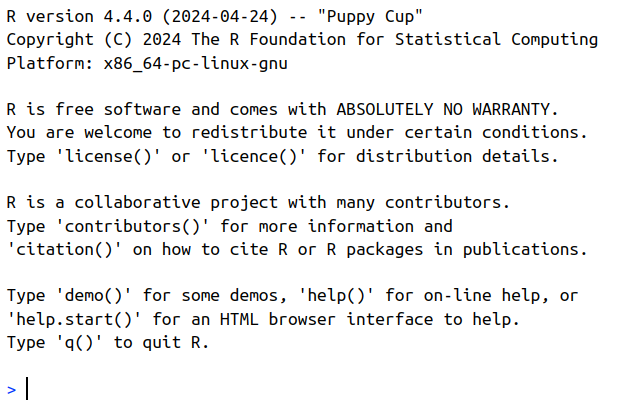

- This is the ‘ugly, old-school’ way of using R
- Still very useful, e.g. testing code on a HPC

## The R Console

- This is often referred to as the `R Console`
- At it’s simplest `R` is just a calculator (Press Enter)

```r
1 + 1
```

```
[1] 2
```

```r
2 * 2
```

```
[1] 4
```

```r
2 ^ 3
```

```
[1] 8
```

- `R` has many standard functions

```r
sqrt(2)
```

```
[1] 1.414214
```

```r
log10(1000)
```

```
[1] 3
```

- We place the value *inside* the brackets *after* the function name

I never use a calculator program on my laptop, always R

## The R Console

We can create objects with names

```r
x <- 5
```

. . .

- We have just created an object called `x`
- The `<-` symbol is like an arrow i.e. “put the value `5` into `x`”
  - Was a single key on keyboards in the 1970s

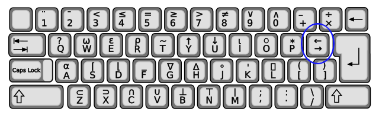

*An APL Keyboard from the 1970s*

Object names can be anything but should start with a letter not a number or special character

## The R Console

- View the contents of the object by entering it’s name in the `Console`

```r
x
```

```
[1] 5
```

- The object `x` only exists in the `R Environment`

. . .

- We can pass objects to functions and perform operations on them

```r
x + 1
```

```
[1] 6
```

```r
sqrt(x)
```

```
[1] 2.236068
```

```r
x^2
```

```
[1] 25
```

```r
x > 1
```

```
[1] TRUE
```

## The R Console

- Everything we’ve just done is trivial
- Real analysis isn’t
- If we perform a series of steps
  - Should we keep a copy of what we’ve done?
  - If so, how should we do that?

. . .

- A common strategy is to record our code as an *R Script*
- `R Studio` makes that easy & convenient
- Many people now use RMarkdown to combine analysis, results and figures

# R Studio

## Introduction to RStudio

`R` and `RStudio` are **two separate but connected things**

- `R` is like the engine of your car

. . .

- `RStudio` is the ‘cabin’ we use to control the engine
  - Comes with extra features un-related to `R` that improve our ‘journey’
  - Known as an IDE (Integrated Development Environment)

. . .

- `R` *does all the calculations, manages the data, generates plots*
  - i.e. gets us to our destination

. . .

- `RStudio` *helps manage our code, display the plots etc*
  - i.e. makes our journey easier to navigate

## What is RStudio

- RStudio is product of a **for profit** company (Posit)
  - RStudio (Desktop) is free
  - RStudio Server has annual licence fee of $’000s
- Posit employs many of the best & brightest package developers
  - e.g. `tidyverse`, `bookdown`, `reticulate`, `roxygen2` etc.
  - The CEO (JJ Allaire) is still an active developer
- Other IDEs also exist (e.g. emacs, VSCode)
- I remember being at the launch of RStudio (Coventry, 2011). It was a room full of R programmers thinking “holy crap, this changes everything”
- RStudio/Posit is a corporation whilst R is an academic-led volunteer community. So far relatively good relationship
- Heard JJ Allaire present some of his latest work a few weeks ago

## Some very helpful features of `RStudio`

- We can write scripts and **execute code** interactively
- Predictive auto-completion
- We can see **everything** we need (directories, plots, code, history etc.)

. . .

- Use `R Projects` to manage each analysis
- Integration with other languages
  - markdown, $\LaTeX$, bash, python, C++, git etc.
- Numerous add-ons to simplify larger tasks

## Important Setup

1. Create a directory on your computer for today’s material
   - We recommend `RAdelaide24` in your home directory

. . .

2. Now open `RStudio`
   - `RStudio` will always open in a directory somewhere
   - Look in the `Files` pane (bottom-right) to see where it’s looking
   - This is also the working directory for `R`

. . .

We want RStudio to be looking in our new directory (`RAdelaide24`)  
$\implies$R Projects make this easy

## Create an R Project

(Not needed for any using the Posit cloud)

`File` > `New Project` > `Existing Directory`

[figure not shown]

- Browse to your `RAdelaide24` directory $\implies$ `Create Project`

## Create an R Project

- The `R Project` name is **always** the directory name
- Not essential, but *good practice* and *extremely useful*
- The Project Menu is in the **top-right** of RStudio
- `R Projects` are simply a wrapper for keeping an analysis organised
  - Will always open in the R Project directory
  - You can easily navigate to a directory with all scripts and data
  - Makes managing file paths from your code **very simple**
- R Projects can be particularly helpful when loading external files
- Also when saving/exporting lots of files as part of your analysis

## Create An Empty R Script

1. `File` > `New File` > `R Script`
2. Save As `DataImport.R`

## RStudio

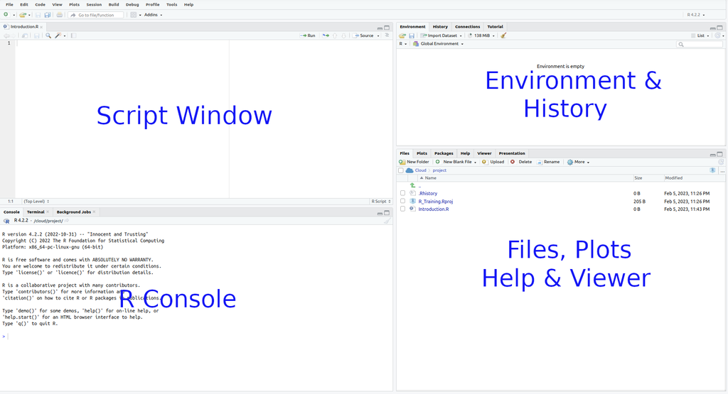

This is the basic layout we often work with

## The Script Window

- This is just a text editor.
- We enter our commands here but they are *not executed*
- Forms a record of **everything** we’ve done
  - Can repeat our analysis exactly
- We’ll return here later $\implies$ but first a quick tour

## The R Console

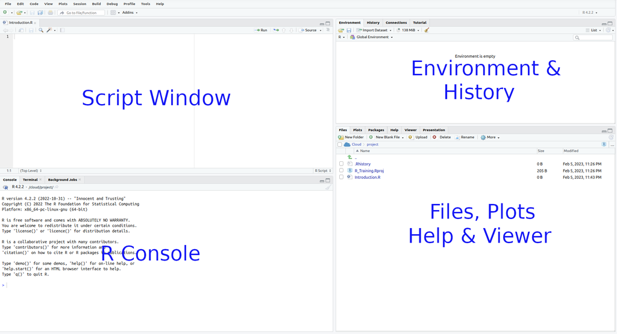

## The R Console

- This is the R Console *within* the RStudio IDE
- We’ve already explored this briefly

. . .

- In the same grouping we also have **Terminal**
  - An approximation of a `bash` terminal (or PowerShell for Windows)

. . .

- **Background Jobs** shows progress when compiling RMarkdown & Quarto
  - Not super relevant

## The R Console

As well as performing simple calculations:

- `R` has what we call an `Environment` (i.e. a Workspace)
- We can define objects here or import data
  - Similar to a workbook in Excel with multiple worksheets
  - **Much more** flexible & powerful
  - Objects aren’t forced to be spreadsheets
- When we create a new sheet in Excel, we’re actually creating an object.
- Most commonly, it’s named Sheet1 or something similar
- Has fixed dimensions for memory management

## The R Environment

Like we did earlier, in the R Console type:

```r
x <- 5
```

. . .

**Where have we created the object `x`?**

- Is it on your hard drive somewhere?
- Is it in a file somewhere?

. . .

- We have placed `x` in our `R Environment`
- Formally known as your `Global Environment`

## The R Environment

- The `R Environment` is like your desktop
- We keep all our relevant objects here
  - Multiple objects are usually created during an analysis
  - Can save all the objects in your environment as a single `.RData` object
  - `R` can be set to automatically save your environment on exit

## The **History** Tab

- Next to the Environment Tab is the **History** Tab
- Keeps a record of the last ~200 lines of code
  - Very useful for remembering steps during exploration
  - Best practice is to enter + execute code from the Script Window

. . .

- We can generally ignore the **Connections** and any other tabs
  - A `git` tab will also appear for those who use git in their project

## Accessing Help

```r
?sqrt
```

- This will take you to the `Help` pane for the `sqrt()` function
  - Contents may look confusing at this point but will become clearer

. . .

- Many inbuilt functions are organised into a package called `base`
  - Packages group similar/related functions together
  - `base` is always installed and loaded with `R`
- Click on the underlined word `Index` at the bottom for a list of functions in the `base` packages
  - **Absolutely no need to learn any of these**
- May be issues with `URL '/help/library/base/html/00Index.html' not found`
- The examples in this help page are a bit rubbish…

## Additional Sources For Help

- Help pages in `R` can be hit & miss
  - Some are excellent and informative $\implies$ some aren’t
- Bioconductor has a support forum for Bioconductor packages
  - All packages have a vignette (again varying quality)

. . .

- Google is your friend $\implies$ maybe ChatGPT?

As a package author, I’m always reading my own help pages. I simply can’t remember everything I’ve written

## The **Plots** Pane

- We’ve already seen the **Files** pane
- Plots appear in the **Plots** pane

```r
plot(cars)
```

[output not shown]

## Other Panes

- The **Packages** Pane is *a bad idea*
  - Can be disabled by popular request (I always do)
  - Temptation to click is strong
  - Very bad for **reproducible research**!!!

. . .

- **Viewer** Pane is used when compiling HTML documents from RMarkdown

. . .

- Every tab can be minimised/maximised using the buttons on the top right
- Window separators can be be moved to resize panes manually

## Cheatsheet and Shortcuts

`Help > Cheatsheets > RStudio IDE Cheat Sheet`

Page 2 has lots of hints:

- `Ctrl + 1` places focus on the Script Window
- `Ctrl + 2` places focus on the Console
- `Ctrl + 3` places focus on the Help Tab

## References

Chambers, John M. 1977. *Computational Methods for Data Analysis*. New York: Wiley.

———. 2020. “S, r, and Data Science.” *Proc. ACM Program. Lang.* 4 (HOPL): 1–17.